# Getting Started with MIMAS

Ben Tonelli

2023-07-18

# Introduction

### What is MIMAS?

Models for the Individual Movements of Avian Species (MIMAS) is a tool to create realistic models of bird movements across the annual cycle. MIMAS relies on individual-based models (IBMs), simulating the movement of individual birds as they move between breeding and wintering sites. MIMAS was built so that other scientists and practitioners can train and use models to answer questions related to bird behavior and broader ecological questions. You can read more about MIMAS in Tonelli et. al, 2023, MEE.

### How is MIMAS used to get species-specific models?

MIMAS relies on eBird Status and Trends relative abundance maps to train species-specific IBMs. How MIMAS does this exactly is a longer discussion (see the paper), but the quick version is that MIMAS tries lots of different possible bird behavioral traits that could explain population-scale patterns by running tons of simulations, and then saves simulations that perform the best.

The output of the MIMAS training process are thousands of parameter sets, which can then be used to run new simulations. Having lots of parameter sets accounts for the uncertainty surrounding the behavioral traits that govern migration.

MIMAS is currently trained for 10 species, listed below. The tutorial will only work (at present) for these 10 species. If there are other species that you are interested in seeing added to this list, please fill out this [form](https://forms.gle/V9bMdBqH7tpCkk8fA), or contact me directly.

1. Brewer’s Sparrow (*Spizella breweri*)
2. Bullock’s Oriole (*Icterus bullockii*)
3. Clay-colored Sparrow (*Spizella pallida*)
4. Hooded Warbler (*Setophaga citrina*)
5. Orchard Oriole (*Icterus spurius*)
6. Red-naped Sapsucker (*Sphyrapicus nuchalis*)
7. Townsend’s Warbler (*Setophaga townsendi*)
8. Varied Thrush (*Ixoreus naevius*)
9. Wood Thrush (*Hylocichla mustelina*)
10. Yellow-bellied Sapsucker (*Sphyrapicus varius*)

### What can MIMAS do for you?

Likely the most useful application of MIMAS is estimating migratory routes of individual birds of a given species. Running a simulation will give you the daily locations of a bunch of birds throughout the year. Below is a short walkthrough of how to run a simulation.

# Code

#### Download MIMAS data, set working directory

To download MIMAS, you’ll need to navigate to the [github page](https://github.com/bentonelli/MIMAS) and [download it as a ZIP file](https://docs.github.com/en/repositories/working-with-files/using-files/downloading-source-code-archives) (or at least, that’s the easiest way to get it).

#### Download eBird ST data

To run the simulations, MIMAS IBMs need the relative abundance of a species at the breeding and wintering grounds. This will give the IBMs the range information neccesary to run the simulations

```r
# Load the eBirdST and other necessary packages (make sure to install, if you don't have these already)
library(ebirdst)
library(raster)
library(sf)
library(lubridate)
library(readr)
library(dplyr)

#Get MIMAS functions
source(file = "scripts/sim_functions/sim_funct.R")

# Now we can download the breeding and wintering relative abundance maps for a particular species of interest from eBird
# We don't want the error maps used for model training, so we can set the "with_error_maps" function to FALSE

# Be warned - this will take ~20 minutes to download and process all the data.
# Luckily, you only need to do this once (for each species, that is!)
spec_to_download <- "Townsend's Warbler"

if(file.exists(paste("data/species_maps/breeding/",gsub(" ", "_", spec_to_download),"_breeding_all",sep="",".csv"))){
  print("You are good to go!")
} else {
  get_spec_maps(spec_to_download,with_error_maps = FALSE)
}
```

[output not shown]

#### Running a simulation

OK, now that the simulation has all the data it needs, we can run a simulation

```r
# Load necessary packages (make sure to install, if you don't have these already)
library(ebirdst)
library(lubridate)
library(geosphere)
library(dplyr)
library(truncnorm)
library(sf)
library(spData)
#Read in functions (you may have just done this in the last code block)
source(file = "scripts/sim_functions/sim_funct.R")

#Define species
species_target <- "Townsend's Warbler"

# Read in parameter set of trained simulations. Make sure to check out which species
# have trained models. Also note these use species 4-letter codes.
param_set <- readRDS("data/output/Spec_IBM_output/TOWA_9_20_22/TOWA_best.rds")

# Check out the structure of this data frame: each row is an accepted simulation
# Each row is a parameter value.
head(param_set[,1:10])
```

```
##              X speed_mean_s speed_sd_s speed_mean_f speed_sd_f start_date_u_s
## 35  err_add.34     366.6116   114.3894     264.9069  147.68078       108.8201
## 44  err_add.43     496.0171   186.0010     134.4196  213.81981       102.0622
## 85  err_add.84     590.4652   428.0007     263.8382   38.57714       104.7679
## 90  err_add.89     586.8561   179.7476     231.9514  185.53872       113.7986
## 137 err_add.36     344.9553   348.2315     144.4236  201.51000       104.1346
## 161 err_add.60     578.2226   116.5893     188.7008   93.13021       103.7410
##     start_date_sd_s start_date_u_f start_date_sd_f max_mig_time_s
## 35         9.062488       241.5033        16.32981            150
## 44        21.575423       242.5887        17.98947            150
## 85        15.567748       244.3561        11.47185            150
## 90        10.990954       235.9102        18.57646            150
## 137       13.310079       238.1036        17.74258            150
## 161       16.001086       240.8870        19.47620            150
```

```r
# We are going to pull one of these simulations/parameter sets at random to use,
# and we are going to save these to the environment
rand_sim <- sample(1:nrow(param_set),1)
for (each_var in 1:ncol(param_set)){
  assign(colnames(param_set)[each_var],param_set[rand_sim,each_var])
}

#Set number of birds to include in simulation, 1000 birds is a reasonable starting point
num_pulls <- 1000

#Set number of days to run the simulation for.
num_days <- 365

#Import breeding, non-breeding maps
breeding_file <- read.csv(paste("data/species_maps/breeding/",gsub(" ","_",species_target),"_breeding_all.csv",sep=""))
nonbreeding_file <- read.csv(paste("data/species_maps/non_breeding/",gsub(" ","_",species_target),"_non_breeding_all.csv",sep=""))

#Define starting season, leave this at 1 (breeding season)
season <- 1

#We will set the start date as the midpoint of the breeding season.
start_date <- (ebirdst_runs[which(ebirdst_runs$common_name==species_target),7:8])
start_date <- as.numeric(start_date[1] + (start_date[2]-start_date[1])/2)
start_date <- yday(as.Date(start_date,origin = "1970-01-01"))
acceptable_week_dates <- seq(1,365,by=7)
start_date <- acceptable_week_dates[which(abs(acceptable_week_dates - start_date) == min(abs(acceptable_week_dates - start_date)))]

#Initialize model using parameters pulled above
initial_dfs <- initialize_MIBM(num_pulls,breeding_file,nonbreeding_file,speed_mean_s,
                               speed_sd_s,speed_mean_f,speed_sd_f,start_date_u_s,
                               start_date_sd_s,start_date_u_f,start_date_sd_f,
                               max_mig_time_s,max_mig_time_f,bear_err_mean_s,
                               bear_err_sd_s,bear_err_mean_f,bear_err_sd_f,
                               max_energy_s,max_energy_f,recovery_rate_s,
                               recovery_rate_f,season,start_date,goal_radius,
                               mig_con,migr_timing_lat_s,migr_timing_lat_f)

# The IBMs rely on two dataframes - one that stays the same (Static) and the other
# that updates based on the location, status of individual birds
static_df <- initial_dfs[[1]]
upd_df <- initial_dfs[[2]]

#Set up a dataframe to record the locations of birds on each day
locs_rec <- as.data.frame(matrix(NA,ncol = 5,nrow = (num_days*num_pulls)))
colnames(locs_rec) <- c("ID","Lon","Lat","Day","Season")
for (days in 1:num_days){
  upd_df <- run_day(upd_df,static_df)
  locs <- save_locations(upd_df,save_season = TRUE)
  loc_ind_s <- (days - 1)*num_pulls + 1
  loc_ind_e <- (days - 1)*num_pulls + num_pulls
  locs_rec[loc_ind_s:loc_ind_e,] <- locs
}
head(locs_rec)
```

```
##   ID       Lon      Lat Day Season
## 1  1 -115.3235 47.91248 184      1
## 2  2 -131.8164 57.33494 184      1
## 3  3 -131.0370 55.42108 184      1
## 4  4 -115.1535 46.52514 184      1
## 5  5 -122.9211 49.42547 184      1
## 6  6 -127.4688 55.06504 184      1
```

So now we have the locations of each simulated bird on each day. We can see what this looks like for a single bird. This code will plot species locations colored by season, with species.

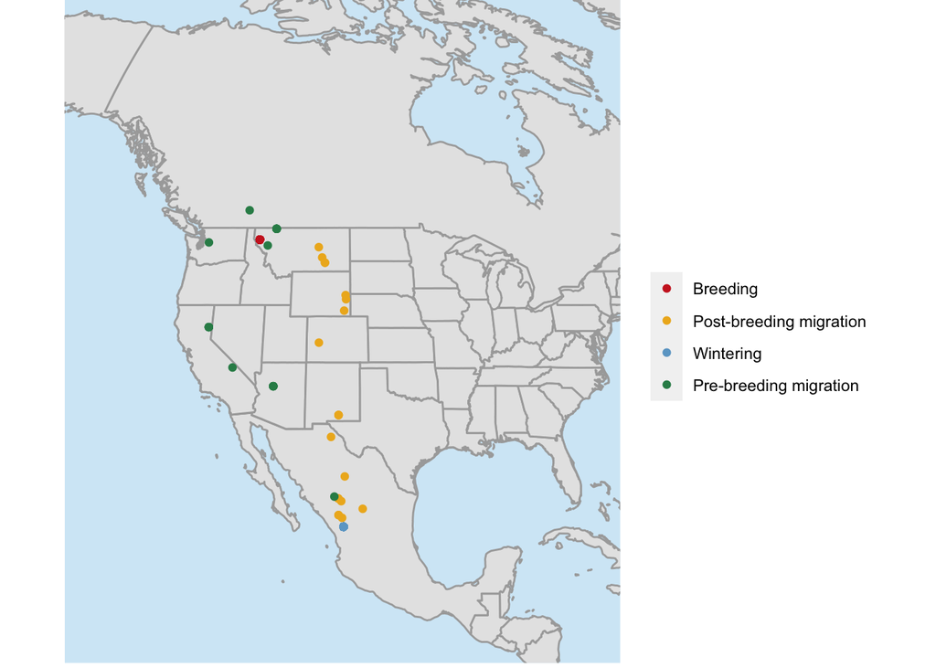

```r
library(dplyr)
library(ggplot2)
single_bird <- locs_rec %>% filter(ID == 1)

countries <- map_data("world")
states <- map_data("state")
countries <- countries %>% filter(long < -32)

p <- ggplot() + coord_map("mollweide",xlim=c(-130,-80),ylim=c(15,70)) +
  geom_polygon(data=countries, aes(x=long, y=lat, group=group), fill="grey90", color="darkgrey") +
  geom_polygon(data=states, aes(x=long, y=lat, group=group), fill="grey90", color="darkgrey") +
  geom_point(data=single_bird,aes(x=Lon,y=Lat,col=as.factor(Season))) +
  scale_colour_manual(values=c("firebrick3","goldenrod2","skyblue3","seagreen"),
                      labels=c("Breeding","Post-breeding migration","Wintering","Pre-breeding migration")) +
  theme(panel.grid.major = element_blank(), panel.grid.minor = element_blank()) +
  theme(axis.ticks.x = element_blank(),axis.text.x = element_blank(),
        axis.ticks.y = element_blank(),axis.text.y = element_blank(),
        axis.title.x=element_blank(),axis.title.y=element_blank(),
        plot.margin = unit(c(0, 0, 0, 0), "null"),
        panel.spacing = unit(c(0, 0, 0, 0), "null"),
        legend.title=element_blank()) +

  theme(panel.background = element_rect(fill = alpha("lightskyblue2",.5)))
print(p)
```